# DAT5003-S2_24-AirQuality-ST20285213-TomRowan

DAT5003 - Applied Data Science

Writ1 - Air Quality Dataset

| **Assessment Code:** | Writ 1, Tasks 1 and 2 |
| --- | --- |
| **Author:** | Tom Rowan, ST20285213 |
| **Course:** | DAT5003_S2_24 |
| **Course Tutor:** | Dr. Angesh Anupam |

> This assignment is designed to assess your ability to formulate relevant and insightful analytic questions based on your chosen dataset. You will need to process the data using key steps of (big) data analytics, including data pre-processing, analysis, and the preparation of an analytical report. Your analysis should address a significant issue that is valuable for stakeholders (e.g., policymakers, businesses) to gain meaningful insights, rather than a trivial topic.

Task 1 - Define Analytic Question

## Task Description

> In this task, choose an analytic question. For your analysis to be compelling it must address a substantive issue useful for the stakeholders (for example, policymakers, businesses) to draw insight rather than a trivial one. Hence you must consider these aspects before choosing a question.

> The analytic questions for Task 1 should be submitted in a .ipynb file. In addition to the questions, you should provide a concise explanation of the rationale behind your chosen question and the expected impact of answering it.

## The Air Quality Dataset

I have chosen to work with the "Air Quality" dataset. The page for this dataset is to be found here: https://archive.ics.uci.edu/dataset/360/air+quality.

The information provided on that website about the dataset is as follows:

> The dataset contains 9358 instances of hourly averaged responses from an array of 5 metal oxide chemical sensors embedded in an Air Quality Chemical Multisensor Device. The device was located on the field in a significantly polluted area, at road level, within an Italian city. Data were recorded from March 2004 to February 2005 (one year)representing the longest freely available recordings of on field deployed air quality chemical sensor devices responses.

> Ground Truth hourly averaged concentrations for CO, Non Metanic Hydrocarbons, Benzene, Total Nitrogen Oxides (NOx) and Nitrogen Dioxide (NO2) and were provided by a co-located reference certified analyzer. Evidences of cross-sensitivities as well as both concept and sensor drifts are present as described in De Vito et al., Sens. And Act. B, Vol. 129,2,2008 (citation required) eventually affecting sensors concentration estimation capabilities.

> Missing values are tagged with -200 value.

This table was created from information provided on the page linked above:

| Variable Name | Type | Description | Units |
| --- | --- | --- | --- |
| Date | Date |  | DD/MM/YYYY |
| Time | Categorical |  | HH.MM.SS |
| T | Continuous | Temperature | °C |
| RH | Continuous | Relative Humidity | % |
| AH | Continuous | Absolute Humidity | g/m<sup>3</sup> |
| CO(GT) | Integer | True hourly averaged concentration CO (reference analyzer) | mg/m<sup>3</sup> |
| NMHC(GT) | Integer | True hourly averaged overall Non Metanic HydroCarbons concentration (reference analyzer) | microg/m<sup>3</sup> |
| C6H6(GT) | Continuous | True hourly averaged Benzene concentration in microg/mm<sup>3</sup> (reference analyzer) | microg/m<sup>3</sup> |
| NOx(GT) | Integer | True hourly averaged NOx concentration in ppb (reference analyzer) | ppb |
| NO2(GT) | Integer | True hourly averaged NO2 concentration in microg/m^3 (reference analyzer) | microg/m<sup>3</sup> |
| PT08.S1(CO) | Categorical | Hourly averaged sensor response (nominally CO targeted) |  |
| PT08.S2(NMHC) | Categorical | Hourly averaged sensor response (nominally NMHC targeted) |  |
| PT08.S3(NOx) | Categorical | Hourly averaged sensor response (nominally NOx targeted) |  |
| PT08.S4(NO2) | Categorical | Hourly averaged sensor response (nominally NO2 targeted) |  |
| PT08.S5(O3) | Categorical | Hourly averaged sensor response (nominally O3 targeted) |  |

In addition, I have researched the following table from Internet sources to give some context to the dataset.

[output not shown]

### Metal Oxide Sensors - Domain Knowledge

The sensor data comes from a metal oxide sensor. According to Fine et al, these work by measuring the way in which "absorption or desorption of a gas on the surface of a metal oxide changes the conductivity of the material. The sensitivity of a surface to a gas can be as low as parts per billion (ppb)". An electric current is passed through a metal oxide plate that is exposed to the air and hence also the pollutant being meaured. Over time, the conductivity of the base material changes in a predictable way, so the levels of pollutant gas present can be inferred. (Fine, 2010)

The larger the area exposed, the more reliable the readings. In metal oxide sensors, bigger is better. This may cause issues with placement of such sensors within an urban environment where space is limited. Furthermore, such sensors require careful and regular calibration to ensure that readings are accurate.

Sensors can also be affected by the presence of other pollutant gases. Ideally, only the gas being measured would be present, but this is unlikely in any practical scenario. "If a contribution to the charge carrier concentration (whether this be an increase or decrease) comes from another gas, the sensor reading will be inaccurate, providing a false measurement." (Fine, 2010)

Gases that can cause such disruption include:

- Ozone
- Water
- Volatile organic compounds such as methyl, ethyl, isopropyl and butyl alcohols. (Note that modern petrols and biodiesel include ethanol.)

**Units of measurement**

Some values for readings are given in mg/m<sup>3</sup>, while some are given in parts per billion (ppb). Converting between these uses a simple formula, given here:

mg/m<sup>3</sup> = 0.0409 X Concentration (ppm) X Molecular weight (g/mol)

(ION Science, 2021)

## My Analytical Questions

Is it possible to predict future pollution levels based on historical data?

And can this data be used to inform residents of the city about potentially risky times, and when to take precautions or to avoid going outside without a mask?

### Rationale for Answering These Questions

It is the aim of this piece of work to assess whether air quality and pollution level data can be analysed using statistical and machine learning models to identify patterns and potentially forecast future pollution levels. The dataset is based on time-series information on pollutants such such as bezene, carbon monoxide and others. There is one year of data, also including atmospheric conditions. It may be possible to predict future levels of pollutants based on past data.

The second question aims to address the practical application of any possible predictions. There is a growing need for proactive public health measures. While some cities - such as London - have introduced sometimes controversial traffic limitation measures (ULEZ), there are many across the globe that have not done so. If reliable forecasts can be made from historical data, these can be used to inform city residents about high-risk periods, enabling them to take preventive actions such as wearing masks, staying indoors, or adjusting the times at which they travel.

If deemed reliable enough, it may even be possible to include results into public SMS based alert systems, or on the local weather forecast. This analysis could be extended to work with datasets from other air quality monitoring stations located in cities across the world, in order to provide a consistent monitoring system for them all.

### Impact

There are a number of possible impacts directly from this study:

- Reduced exposure to pollutants, particularly for the vulnerable such as those with respiratory conditions, or young children.
- Support for policy and planning initiatives, especially in the city where the data originated. Forecasting can be used to implement traffic (or other) restrictions during times when high levels are predicted.
- Public health awareness may increase, which may result in voluntary reductions of pollution any levels by residents. This might include them switching to public transport and/or electric vehicles.

This dataset only refers to a single environmental monitoring station on a single city in 2004. However, there are many such stations in many cities at the time of writing (2025), so the impact of being able to make predictions could be implemented worldwide. For example. here in Wales, the Welsh Goverment already provides data online: https://www.airquality.gov.wales/air-pollution/monitoring-site-summary.

According to the Welsh Government "air pollution in the UK reduces the life expectancy of every person by an average of 7–8 months, with an associated cost of up to £20 billion each year." (WelshGov, 2025). There is clearly good reason to perform useful analysis and predictions.

## References

1. EU (2022), *World Health Organization (WHO) air quality guidelines (AQGs) and estimated reference levels (RLs)* https://www.eea.europa.eu/publications/status-of-air-quality-in-Europe-2022/europes-air-quality-status-2022/world-health-organization-who-air. (Accessed 23/05/2025)
2. Fine GF, Cavanagh LM, Afonja A, Binions R. (2010), *Metal Oxide Semi-Conductor Gas Sensors in Environmental Monitoring*, https://pmc.ncbi.nlm.nih.gov/articles/PMC3247717/ (Accessed 15/05/2025)
3. ION Science (2021), *Whitepaper Article: PPM to mg/m3*, https://distributors.ionscience.com/wp-content/uploads/2021/07/ppm-to-mgm3-Whitepaper.pdf (Accessed 23/05/2025)
4. Lane, E. (2021) *Understanding occupational exposure limits for benzene.* https://ionscience.com/en/news/understanding-occupational-exposure-limits-for-benzene/ (Accessed 25/05/2025)
5. UKGov (2022), *Carbon monoxide: general information*, https://www.gov.uk/government/publications/carbon-monoxide-properties-incident-management-and-toxicology/carbon-monoxide-general-information. (Accessed 23/05/2025)
6. UKGov (2024) *Monitoring ambient air: data analysis techniques*. https://www.gov.uk/guidance/monitoring-ambient-air-data-analysis-techniques (Accessed 28/04/2025)
7. UKGov (2025), Emissions of air pollutants. https://www.gov.uk/government/statistics/emissions-of-air-pollutants. (Accessed 25/05/2025)
8. US EPA (2024) *Basic Information about NO2*, https://www.epa.gov/no2-pollution/basic-information-about-no2. (Accessed 23/05/2025)
9. US EPA (2025), *Ground-level Ozone Basics*, https://www.epa.gov/ground-level-ozone-pollution/ground-level-ozone-basics#formation (Accessed 23/05/2025)
10. WelshGov (2025) *About air quality | Air quality in Wales*. https://www.airquality.gov.wales/about-air-quality. (Accessed 23/05/2025)
11. WHO (2021) *WHO global air quality guidelines*, https://iris.who.int/bitstream/handle/10665/345329/9789240034228-eng.pdf (Accessed 25/05/2025)
12. Wikipedia (2025) *NOx*, https://en.wikipedia.org/wiki/NOx. (Accessed 23/05/2025)
13. Winkler, S.L. et al. (2018) *Vehicle criteria pollutant (PM, NOx, CO, HCs) emissions: how low should we go?* https://doi.org/10.1038/s41612-018-0037-5 (Accessed 23/05/2025)

Task 2 - Data Analysis

Coding Syntax Note: _variable_name --> temporary / locally used variable, discarded after use.

```python
# Install Requirements Using Pip
%pip install pip --upgrade
%pip install -r requirements.txt
```

```python
# Import Standard Python Libraries
from urllib import request
import math

# Pandas and numpy
import pandas as pd
import numpy as np

# Matplot Lib
import matplotlib.pyplot as plt
from matplotlib import colormaps
from matplotlib.pyplot import figure
%matplotlib inline

# SciKit Learn
from sklearn.impute import KNNImputer
from sklearn.model_selection import GridSearchCV, KFold

from sklearn.preprocessing import normalize
from sklearn.preprocessing import MinMaxScaler
from sklearn.preprocessing import StandardScaler

from sklearn.model_selection import train_test_split
from sklearn.metrics import r2_score
from sklearn.metrics import mean_squared_error

# Sysidentpy - NARMAX Library
from sysidentpy.general_estimators import NARX
from sklearn.linear_model import BayesianRidge
from sysidentpy.basis_function import Polynomial

# Seaborn Graphs
import seaborn as sns

# Tabulate
from tabulate import tabulate

# Colorama
from colorama import Fore

# Do not print warnings!
import warnings
warnings.filterwarnings('ignore')
```

The following function checks for Internet connectivity while running this notebook and will load the dataset from the Internet if possible. Otherwise, it assumes that a local copy is available.

```python
# Coding Syntax Note: _variable_name --> temporary / locally used variable, discarded after use.

def check_internet(url_list):
    # We only need the first 200 code to prove a connection.
    online = False
    for _url in url_list:
        try:
            request.urlopen(_url, timeout=3)
            online = True
            break
        except request.URLError as err:
            print (f"{Fore.RED}[FAIL]{Fore.RESET} Check Internet failed for {_url}")
        finally:
            return online

# Check for Internet Connectivity

online = False
_urls_to_check = ['http://connectivitycheck.gstatic.com/generate_204',
                  'https://github.com',
                  'https://cardiffmet.ac.uk']

if check_internet(_urls_to_check ) == True:
    print (f"{Fore.GREEN}[INTERNET]{Fore.RESET} Internet Connectivity Detected. Using Internet resources.")
    online = True

else:
    print (f"{Fore.YELLOW}[INTERNET]{Fore.RESET} No Internet Connectivity. Using local resources.")
```

```
[INTERNET] Internet Connectivity Detected. Using Internet resources.
```

The data originally comes from: https://archive.ics.uci.edu/dataset/360/air+. I have made a verbatim copy onto my website as a backup.

```python
if online:
  #dataset_url = 'https://archive.ics.uci.edu/static/public/360/data.csv'
  dataset_url = 'https://datascience.daemonchild.com/year2/dat5003/writ1/datasets/pollution_sensor_data.csv'
  print (f"{Fore.YELLOW}[DATASET]{Fore.RESET} Fetching Dataset from {dataset_url}")
  df = pd.read_csv(dataset_url)
else:
  print (f"{Fore.YELLOW}[DATASET]{Fore.RESET} Using local dataset.")
  df = pd.read_csv('air_quality_data.csv')
```

```
[DATASET] Fetching Dataset from https://datascience.daemonchild.com/year2/dat5003/writ1/datasets/pollution_sensor_data.csv
```

# Exploratory Data Analysis (EDA) and Preprocessing

In this section of the notebook, I will use python code and create some charts to explore the 'shape and feel' of the dataset before attempting to answer the question set out above. In this basic analysis, I will preprocess the data to deal with missing values, and extend the dataset by adding features that can be calulated or implied from the provided data.

```python
print (f"{Fore.YELLOW}[EDA]{Fore.RESET} column names (feature names), alphabetically:")
for column in df.columns.sort_values():
    print (f"{Fore.CYAN} - {Fore.RESET} {column}")
```

```
[EDA] column names (feature names), alphabetically:
 -  AH
 -  C6H6(GT)
 -  CO(GT)
 -  Date
 -  NMHC(GT)
 -  NO2(GT)
 -  NOx(GT)
 -  PT08.S1(CO)
 -  PT08.S2(NMHC)
 -  PT08.S3(NOx)
 -  PT08.S4(NO2)
 -  PT08.S5(O3)
 -  RH
 -  T
 -  Time
```

```python
print (f"{Fore.YELLOW}[EDA]{Fore.RESET} Dataset has {df.shape[0]} rows and {df.shape[1]} columns.\n")

print (f"{Fore.YELLOW}[EDA]{Fore.RESET} A random sample of 10 rows from the dataset is shown below:\n")
print(tabulate(df.sample(10), headers='keys', tablefmt='grid'))
```

```
[EDA] Dataset has 9357 rows and 15 columns.

[EDA] A random sample of 10 rows from the dataset is shown below:

+------+-----------+----------+----------+---------------+------------+------------+-----------------+-----------+----------------+-----------+----------------+---------------+------+------+--------+
|      | Date      | Time     |   CO(GT) |   PT08.S1(CO) |   NMHC(GT) |   C6H6(GT) |   PT08.S2(NMHC) |   NOx(GT) |   PT08.S3(NOx) |   NO2(GT) |   PT08.S4(NO2) |   PT08.S5(O3) |    T |   RH |     AH |
+======+===========+==========+==========+===============+============+============+=================+===========+================+===========+================+===============+======+======+========+
| 8236 | 2/16/2005 | 22:00:00 |      2.8 |          1177 |       -200 |       10.7 |            1004 |       408 |            640 |       216 |           1111 |          1341 |  5   | 46.6 | 0.4099 |
+------+-----------+----------+----------+---------------+------------+------------+-----------------+-----------+----------------+-----------+----------------+---------------+------+------+--------+
| 5670 | 11/2/2004 | 0:00:00  |      2.3 |          1122 |       -200 |       10.5 |             996 |       259 |            660 |        62 |           1586 |          1048 | 18.4 | 76.3 | 1.6017 |
+------+-----------+----------+----------+---------------+------------+------------+-----------------+-----------+----------------+-----------+----------------+---------------+------+------+--------+
| 3409 | 7/30/2004 | 19:00:00 |   -200   |          1153 |       -200 |       16.5 |            1194 |       116 |            628 |       137 |           1874 |          1038 | 33.3 | 28.7 | 1.4454 |
+------+-----------+----------+----------+---------------+------------+------------+-----------------+-----------+----------------+-----------+----------------+---------------+------+------+--------+
| 2578 | 6/26/2004 | 4:00:00  |   -200   |           763 |       -200 |        2.5 |             622 |        37 |           1129 |        58 |           1321 |           689 | 21.2 | 39.4 | 0.9802 |
+------+-----------+----------+----------+---------------+------------+------------+-----------------+-----------+----------------+-----------+----------------+---------------+------+------+--------+
| 5050 | 10/7/2004 | 4:00:00  |   -200   |           924 |       -200 |        2.9 |             643 |      -200 |            948 |      -200 |           1329 |           825 | 19.9 | 66.1 | 1.5198 |
+------+-----------+----------+----------+---------------+------------+------------+-----------------+-----------+----------------+-----------+----------------+---------------+------+------+--------+
| 4751 | 9/24/2004 | 17:00:00 |      2.2 |          1134 |       -200 |       11.1 |            1017 |       268 |            724 |       107 |           1632 |           981 | 18.3 | 75.4 | 1.5682 |
+------+-----------+----------+----------+---------------+------------+------------+-----------------+-----------+----------------+-----------+----------------+---------------+------+------+--------+
| 8641 | 3/5/2005  | 19:00:00 |      2.5 |          1161 |       -200 |        9.1 |             945 |       344 |            654 |       177 |           1205 |          1077 |  8.5 | 57.9 | 0.6435 |
+------+-----------+----------+----------+---------------+------------+------------+-----------------+-----------+----------------+-----------+----------------+---------------+------+------+--------+
| 7953 | 2/5/2005  | 3:00:00  |      1.6 |          1105 |       -200 |        6.4 |             828 |      -200 |            735 |      -200 |            997 |          1157 |  2.1 | 64.2 | 0.4633 |
+------+-----------+----------+----------+---------------+------------+------------+-----------------+-----------+----------------+-----------+----------------+---------------+------+------+--------+
| 9016 | 3/21/2005 | 10:00:00 |      4.3 |          1403 |       -200 |       15.4 |            1161 |       614 |            487 |       178 |           1576 |          1583 | 15.9 | 56.6 | 1.0147 |
+------+-----------+----------+----------+---------------+------------+------------+-----------------+-----------+----------------+-----------+----------------+---------------+------+------+--------+
| 1317 | 5/4/2004  | 15:00:00 |      2.6 |          1197 |       -200 |       12.9 |            1082 |       140 |            753 |        97 |           1851 |           971 | 19.9 | 57.1 | 1.3158 |
+------+-----------+----------+----------+---------------+------------+------------+-----------------+-----------+----------------+-----------+----------------+---------------+------+------+--------+
```

```python
print (f"{Fore.YELLOW}[EDA]{Fore.RESET} Basic statistical information about the dataset:")
print(tabulate(df.describe(), headers='keys', tablefmt='grid'))
```

```
[EDA] Basic statistical information about the dataset:
+-------+-----------+---------------+------------+------------+-----------------+-----------+----------------+-----------+----------------+---------------+------------+-----------+-----------+
|       |    CO(GT) |   PT08.S1(CO) |   NMHC(GT) |   C6H6(GT) |   PT08.S2(NMHC) |   NOx(GT) |   PT08.S3(NOx) |   NO2(GT) |   PT08.S4(NO2) |   PT08.S5(O3) |          T |        RH |        AH |
+=======+===========+===============+============+============+=================+===========+================+===========+================+===============+============+===========+===========+
| count | 9357      |      9357     |   9357     | 9357       |        9357     |  9357     |       9357     | 9357      |        9357    |      9357     | 9357       | 9357      | 9357      |
+-------+-----------+---------------+------------+------------+-----------------+-----------+----------------+-----------+----------------+---------------+------------+-----------+-----------+
| mean  |  -34.2075 |      1048.99  |   -159.09  |    1.86568 |         894.595 |   168.617 |        794.99  |   58.1489 |        1391.48 |       975.072 |    9.77831 |   39.4854 |   -6.8376 |
+-------+-----------+---------------+------------+------------+-----------------+-----------+----------------+-----------+----------------+---------------+------------+-----------+-----------+
| std   |   77.6572 |       329.833 |    139.789 |   41.3802  |         342.333 |   257.434 |        321.994 |  126.94   |         467.21 |       456.938 |   43.2036  |   51.2161 |   38.9767 |
+-------+-----------+---------------+------------+------------+-----------------+-----------+----------------+-----------+----------------+---------------+------------+-----------+-----------+
| min   | -200      |      -200     |   -200     | -200       |        -200     |  -200     |       -200     | -200      |        -200    |      -200     | -200       | -200      | -200      |
+-------+-----------+---------------+------------+------------+-----------------+-----------+----------------+-----------+----------------+---------------+------------+-----------+-----------+
| 25%   |    0.6    |       921     |   -200     |    4       |         711     |    50     |        637     |   53      |        1185    |       700     |   10.9     |   34.1    |    0.6923 |
+-------+-----------+---------------+------------+------------+-----------------+-----------+----------------+-----------+----------------+---------------+------------+-----------+-----------+
| 50%   |    1.5    |      1053     |   -200     |    7.9     |         895     |   141     |        794     |   96      |        1446    |       942     |   17.2     |   48.6    |    0.9768 |
+-------+-----------+---------------+------------+------------+-----------------+-----------+----------------+-----------+----------------+---------------+------------+-----------+-----------+
| 75%   |    2.6    |      1221     |   -200     |   13.6     |        1105     |   284     |        960     |  133      |        1662    |      1255     |   24.1     |   61.9    |    1.2962 |
+-------+-----------+---------------+------------+------------+-----------------+-----------+----------------+-----------+----------------+---------------+------------+-----------+-----------+
| max   |   11.9    |      2040     |   1189     |   63.7     |        2214     |  1479     |       2683     |  340      |        2775    |      2523     |   44.6     |   88.7    |    2.231  |
+-------+-----------+---------------+------------+------------+-----------------+-----------+----------------+-----------+----------------+---------------+------------+-----------+-----------+
```

According to the dataset page "missing values are tagged with -200 value." (UC Irvine datset page)

This is clearly shown in the analysis above using the 'describe' function, as the CO(GT) feature has a mean value of -34.2, which is nonsensical.

The following code shows the prevalence of missing values per column by counting '-200' throughout the data set, sorting in descending order, and then converting to a percentage of the total number of rows.

It is clearly shown that the NMHC(GT) feature column contains mostly empty values. I have decided to remove this column from the dataset as it will not be possible to recover from this by imputing values, or averaging out across the dataset.

```python
no_rows = df.shape[0]
(df == -200).sum().sort_values(ascending=False).apply(lambda x: f"{Fore.CYAN}{x}{Fore.RESET} -> {Fore.YELLOW}{round(x/no_rows*100, 1)}%{Fore.RESET}")
```

```
NMHC(GT)         8443 -> 90.2%
CO(GT)           1683 -> 18.0%
NO2(GT)          1642 -> 17.5%
NOx(GT)          1639 -> 17.5%
PT08.S1(CO)        366 -> 3.9%
C6H6(GT)           366 -> 3.9%
PT08.S2(NMHC)      366 -> 3.9%
PT08.S3(NOx)       366 -> 3.9%
PT08.S4(NO2)       366 -> 3.9%
PT08.S5(O3)        366 -> 3.9%
T                  366 -> 3.9%
RH                 366 -> 3.9%
AH                 366 -> 3.9%
Date                 0 -> 0.0%
Time                 0 -> 0.0%
dtype: object
```

```python
# Drop the 'NMHC(GT)' column as is it mostly empty values.
df.drop(columns='NMHC(GT)', inplace=True)
```

## Feature Engineering

As part of the exploration and preprocessing process, here I will use existing data to generate a number of useful features to allow further processing and analysis of the data set.

### Dates, Times and Days

From the 'Date' and 'Time' fields, it is simple to create a combined 'Date-and-Time' ('Datetime') feature. It is equally simple to split out the 'Time' field into a simpler 'Hour' feature.

- Datetime (combined)
- Hour of the day (24 hour clock)
- Day of the week (and day number)
- Month (and month number)

The weekday and months of the year require a custom ordering to be created, and they hjave been converted to the categorial data type.

```python
# Create 'Datetime'
df['Datetime'] = pd.to_datetime(df['Date'] + ' ' + df['Time'])

# Create 'Hour' by splitting the Time field
# For example, 13:00:00 -> 13
df['Hour'] = df['Time'].apply(lambda x: int(x.split(':')[0]))

# Create 'Weekday' and 'WeekdayNo'
df['Weekday'] = df['Datetime'].dt.day_name()
df['WeekdayNo'] = df['Datetime'].dt.dayofweek

# Create 'Weekday' and 'WeekdayNo'
df['Month'] = df['Datetime'].dt.month_name()
df['MonthNo'] = df['Datetime'].dt.month

# Create a custom order for the days of the week, or it will be alphabetical
weekday_custom_order = ['Monday', 'Tuesday', 'Wednesday', 'Thursday', 'Friday', 'Saturday', 'Sunday']
month_custom_order = ['January', 'February', 'March', 'April', 'May', 'June', 'July', 'August', 'September', 'October', 'November', 'December']

# Convert 'Weekday' to a categorical type uasing the custom order
df['Weekday'] = pd.Categorical(df['Weekday'], categories=weekday_custom_order, ordered=True)
df['Month'] = pd.Categorical(df['Month'], categories=month_custom_order, ordered=True)

# Check the data types for the new features:
# (df.dtypes creatres a series object, so need to recombine with the column names keeping their order the same!)

print (f"{Fore.YELLOW}[EDA]{Fore.RESET} Data types for the new features:")

dtypes_table = [(column, dtype) for column, dtype in zip(df.columns, df.dtypes)]
print(tabulate(dtypes_table, headers=["Feature", "Data Type"], tablefmt="grid"))
```

```
[EDA] Data types for the new features:
+---------------+----------------+
| Feature       | Data Type      |
+===============+================+
| Date          | object         |
+---------------+----------------+
| Time          | object         |
+---------------+----------------+
| CO(GT)        | float64        |
+---------------+----------------+
| PT08.S1(CO)   | int64          |
+---------------+----------------+
| C6H6(GT)      | float64        |
+---------------+----------------+
| PT08.S2(NMHC) | int64          |
+---------------+----------------+
| NOx(GT)       | int64          |
+---------------+----------------+
| PT08.S3(NOx)  | int64          |
+---------------+----------------+
| NO2(GT)       | int64          |
+---------------+----------------+
| PT08.S4(NO2)  | int64          |
+---------------+----------------+
| PT08.S5(O3)   | int64          |
+---------------+----------------+
| T             | float64        |
+---------------+----------------+
| RH            | float64        |
+---------------+----------------+
| AH            | float64        |
+---------------+----------------+
| Datetime      | datetime64[ns] |
+---------------+----------------+
| Hour          | int64          |
+---------------+----------------+
| Weekday       | category       |
+---------------+----------------+
| WeekdayNo     | int32          |
+---------------+----------------+
| Month         | category       |
+---------------+----------------+
| MonthNo       | int32          |
+---------------+----------------+
```

Now I will extract lists of like features from the columns of the dataset:

```python
# Extract 'Ground True concentration' fields
gt_fields = [column for column in list(df.columns) if "GT" in column]

# Extract pt08 fields
pt08_fields = [column for column in list(df.columns) if "PT08" in column]

# List of atmospheric fields
atmos_fields = ['AH','RH','T']
```

The following function draws multiple graphs in one large plot.

```python
def plot_graph_grid_line(df, fields_to_plot, x_field, graphs_per_row=3, y_label = ""):

    # Calculate the number of rows needed for the subplots
    _no_fields_to_plot = len(fields_to_plot)
    _graph_rows = math.ceil( (_no_fields_to_plot / graphs_per_row))

    # Create new plot grid (share x-axis for space, no shared y-axis to allow different scales)
    fig, axs = plt.subplots(_graph_rows,graphs_per_row, figsize=(18, 18), sharex=True, sharey=False, constrained_layout=True)

    # Set the starting location ot the top left corner of the grid
    _location_x = _location_y = 0

    # Loop through the fields to create subplots
    for _field in fields_to_plot:

        print (f"{Fore.YELLOW}[PLOT]{Fore.RESET} Plotting field: {_field}")

        # Make a new filtered dataframe
        plot_df = df[[x_field, _field]]

        # Replace -200 with NaN and drop NaN values
        plot_df[_field].replace(-200, np.nan, inplace=True)
        #plot_df.dropna(inplace=True)

        # Plot the chart at the correct location in the grid
        plot_df.plot(kind='line',x=x_field, y=_field, ax=axs[_location_x, _location_y], subplots=True, legend=False, linewidth=0.5, color='#25a983')

        # Labels
        axs[_location_x, _location_y].set_title(_field)
        axs[_location_x, _location_y].set_xlabel(x_field)
        axs[_location_x, _location_y].set_ylabel(y_label)

        # Move to the next location in the grid
        if _location_y < (graphs_per_row - 1):
            _location_y += 1
        else:
            _location_y = 0
            _location_x += 1
```

Here I am going to draw some exploratory graphs of each field in the GT field set.

```
[PLOT] Plotting field: CO(GT)
[PLOT] Plotting field: C6H6(GT)
[PLOT] Plotting field: NOx(GT)
[PLOT] Plotting field: NO2(GT)
[PLOT] Plotting field: PT08.S1(CO)
[PLOT] Plotting field: PT08.S2(NMHC)
[PLOT] Plotting field: PT08.S3(NOx)
[PLOT] Plotting field: PT08.S4(NO2)
[PLOT] Plotting field: PT08.S5(O3)
[PLOT] Plotting field: AH
[PLOT] Plotting field: RH
[PLOT] Plotting field: T
```

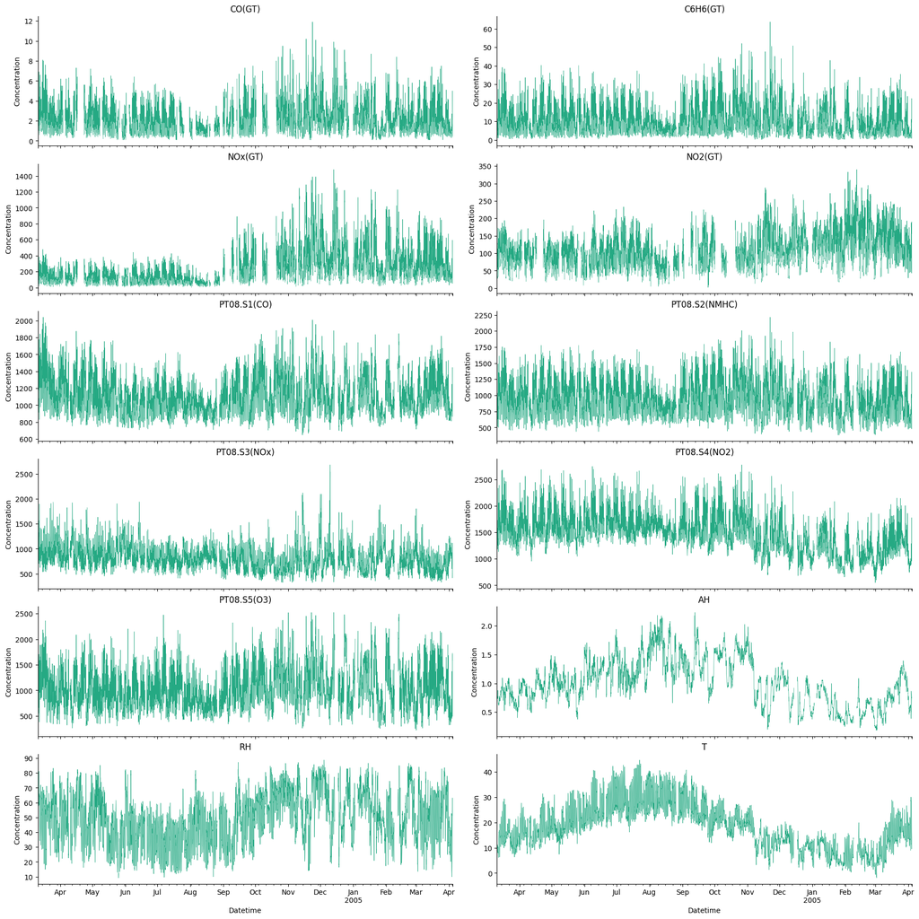

```python
fields_to_plot = gt_fields + pt08_fields + atmos_fields
plot_graph_grid_line(df, fields_to_plot, 'Datetime', graphs_per_row=2, y_label='Concentration')
```

## Fill in Missing Values

Reviewing the graphs above shows that there is some impact from missing values.

This can be more easily seen in this small section of the CO(GT) graph. The missing values are quite clear where the plot 'jumps' suddenly between values.

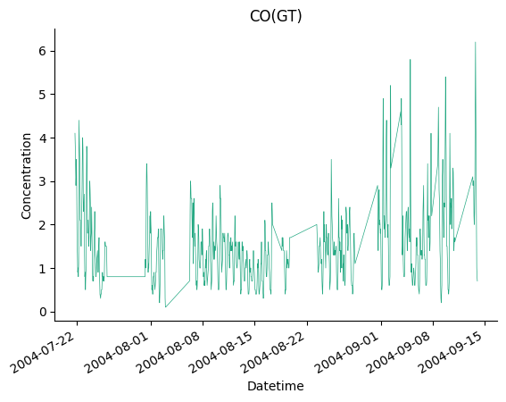

```python
# Filter the dataframe
plot_df = df[['CO(GT)', 'Datetime']]
plot_df = plot_df[(plot_df['Datetime'] >= '2004/07/20') & (plot_df['Datetime'] <= '2004/09/15')]

# Replace -200 with NaN and drop NaN values
plot_df['CO(GT)'].replace(-200, np.nan, inplace=True)
plot_df.dropna(inplace=True)

# Plot the chart
# Set the figure size
figure(figsize=(16, 12))
plot_df.plot(kind='line',x='Datetime', y='CO(GT)', legend=False, linewidth=0.5,color='#25a983')

# Labels
plt.title('CO(GT)')
plt.xlabel('Datetime')
plt.ylabel('Concentration')
plt.show();
```

I am going to use the K Nearest Neighbours algorithm to impute the missing values from the surrounding data.

Firstly, I am going to use the GridSearchCV (Grid Search with Cross Validation) algorithm to determine the best value for the number of neighbours to use. I will use KFold for cross validation.

(https://scikit-learn.org/stable/modules/impute.html)

```python
# The KNNImputer function will fill NULL values, so the -200 must be replaced
df.replace(-200, np.nan, inplace=True)

no_rows = df.shape[0]
df.isna().sum().sort_values(ascending=False).apply(lambda x: f"{Fore.CYAN}{x}{Fore.RESET} -> {Fore.YELLOW}{round(x/no_rows*100, 1)}%{Fore.RESET}")
```

```
CO(GT)           1683 -> 18.0%
NO2(GT)          1642 -> 17.5%
NOx(GT)          1639 -> 17.5%
PT08.S5(O3)        366 -> 3.9%
PT08.S1(CO)        366 -> 3.9%
C6H6(GT)           366 -> 3.9%
PT08.S2(NMHC)      366 -> 3.9%
PT08.S3(NOx)       366 -> 3.9%
PT08.S4(NO2)       366 -> 3.9%
T                  366 -> 3.9%
RH                 366 -> 3.9%
AH                 366 -> 3.9%
Weekday              0 -> 0.0%
Month                0 -> 0.0%
WeekdayNo            0 -> 0.0%
Date                 0 -> 0.0%
Hour                 0 -> 0.0%
Datetime             0 -> 0.0%
Time                 0 -> 0.0%
MonthNo              0 -> 0.0%
dtype: object
```

```python
# Optimise the value for the number of neighbours
# Reference: https://www.geeksforgeeks.org/how-to-find-the-optimal-value-of-k-in-knn/

# Define the fields to work with
impute_these_fields = gt_fields + pt08_fields + atmos_fields

# Define the range of k values to test
k_values = {'n_neighbors': list(range(1, 21))}

print (f"{Fore.CYAN}K_Values: {Fore.RESET}{k_values}")

# Initialise KNNImputer
knn_imputer = KNNImputer()

# Perform grid search with cross-validation
grid_search = GridSearchCV(knn_imputer, param_grid=k_values, cv=KFold(n_splits=5), scoring='neg_mean_squared_error')
grid_search.fit(df[impute_these_fields])

# Best k value
best_k = grid_search.best_params_['n_neighbors']
print(f"{Fore.CYAN}Optimal number of neighbours: {Fore.RESET} {best_k}")
```

```
K_Values: {'n_neighbors': [1, 2, 3, 4, 5, 6, 7, 8, 9, 10, 11, 12, 13, 14, 15, 16, 17, 18, 19, 20]}
Optimal number of neighbours:  1
```

```python
# Run the KNNImputer with the best k value
neighbours = best_k

# Create a new KNNImputer with the optimal number of neighbours
imputer = KNNImputer(n_neighbors=neighbours, weights="uniform")
imputer.fit_transform(df[impute_these_fields])
df[impute_these_fields] = imputer.fit_transform(df[impute_these_fields])
```

Check that all NULL values were filled in:

```python
no_rows = df.shape[0]
df.isna().sum().sort_values(ascending=False).apply(lambda x: f"{Fore.CYAN}{x}{Fore.RESET} -> {Fore.YELLOW}{round(x/no_rows*100, 1)}%{Fore.RESET}")
```

```
Date             0 -> 0.0%
Time             0 -> 0.0%
Month            0 -> 0.0%
WeekdayNo        0 -> 0.0%
Weekday          0 -> 0.0%
Hour             0 -> 0.0%
Datetime         0 -> 0.0%
AH               0 -> 0.0%
RH               0 -> 0.0%
T                0 -> 0.0%
PT08.S5(O3)      0 -> 0.0%
PT08.S4(NO2)     0 -> 0.0%
NO2(GT)          0 -> 0.0%
PT08.S3(NOx)     0 -> 0.0%
NOx(GT)          0 -> 0.0%
PT08.S2(NMHC)    0 -> 0.0%
C6H6(GT)         0 -> 0.0%
PT08.S1(CO)      0 -> 0.0%
CO(GT)           0 -> 0.0%
MonthNo          0 -> 0.0%
dtype: object
```

Redrawing the zoomed CO(GT) graph to show how the missing values have been filled:

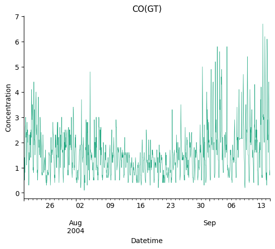

```python
# Filter the dataframe
plot_df = df[['CO(GT)', 'Datetime']]
plot_df = plot_df[(plot_df['Datetime'] >= '2004/07/20') & (plot_df['Datetime'] <= '2004/09/15')]

# Plot the chart
# Set the figure size
figure(figsize=(16, 12))
plot_df.plot(kind='line',x='Datetime', y='CO(GT)', legend=False, linewidth=0.5, color='#25a983')

# Labels
plt.title('CO(GT)')
plt.xlabel('Datetime')
plt.ylabel('Concentration')
plt.show();
```

```python
print (f"{Fore.YELLOW}[EDA]{Fore.RESET} Basic statistical information about the imputed dataset:")
print(tabulate(df.describe(), headers='keys', tablefmt='grid'))
```

```
[EDA] Basic statistical information about the imputed dataset:
+-------+------------+---------------+------------+-----------------+-----------+----------------+-----------+----------------+---------------+------------+-----------+-------------+---------------------+------------+-------------+------------+
|       |     CO(GT) |   PT08.S1(CO) |   C6H6(GT) |   PT08.S2(NMHC) |   NOx(GT) |   PT08.S3(NOx) |   NO2(GT) |   PT08.S4(NO2) |   PT08.S5(O3) |          T |        RH |          AH | Datetime            |       Hour |   WeekdayNo |    MonthNo |
+=======+============+===============+============+=================+===========+================+===========+================+===============+============+===========+=============+=====================+============+=============+============+
| count | 9357       |      9357     |  9357      |        9357     |  9357     |       9357     | 9357      |       9357     |       9357    | 9357       | 9357      | 9357        | 9357                | 9357       |  9357       | 9357       |
+-------+------------+---------------+------------+-----------------+-----------+----------------+-----------+----------------+---------------+------------+-----------+-------------+---------------------+------------+-------------+------------+
| mean  |    2.08753 |      1101.05  |    10.176  |         942.348 |   232.055 |        836.928 |  108.069  |       1461.09  |       1025.89 |   18.4075  |   49.1085 |    1.0254   | 2004-09-21 16:00:00 |   11.4986  |     3.00994 |    6.31036 |
+-------+------------+---------------+------------+-----------------+-----------+----------------+-----------+----------------+---------------+------------+-----------+-------------+---------------------+------------+-------------+------------+
| min   |    0.1     |       647     |     0.1    |         383     |     2     |        322     |    2      |        551     |        221    |   -1.9     |    9.2    |    0.1847   | 2004-03-10 18:00:00 |    0       |     0       |    1       |
+-------+------------+---------------+------------+-----------------+-----------+----------------+-----------+----------------+---------------+------------+-----------+-------------+---------------------+------------+-------------+------------+
| 25%   |    1       |       939     |     4.5    |         737     |    88     |        658     |   72      |       1238     |        738    |   11.8     |   35.6    |    0.7402   | 2004-06-16 05:00:00 |    5       |     1       |    3       |
+-------+------------+---------------+------------+-----------------+-----------+----------------+-----------+----------------+---------------+------------+-----------+-------------+---------------------+------------+-------------+------------+
| 50%   |    1.7     |      1066     |     8.3    |         913     |   166     |        808     |  104      |       1466     |        969    |   17.8     |   49.4    |    0.9978   | 2004-09-21 16:00:00 |   11       |     3       |    6       |
+-------+------------+---------------+------------+-----------------+-----------+----------------+-----------+----------------+---------------+------------+-----------+-------------+---------------------+------------+-------------+------------+
| 75%   |    2.8     |      1230     |    14      |        1117     |   305     |        970     |  136      |       1678     |       1276    |   24.5     |   62.5    |    1.3073   | 2004-12-28 03:00:00 |   18       |     5       |    9       |
+-------+------------+---------------+------------+-----------------+-----------+----------------+-----------+----------------+---------------+------------+-----------+-------------+---------------------+------------+-------------+------------+
| max   |   11.9     |      2040     |    63.7    |        2214     |  1479     |       2683     |  340      |       2775     |       2523    |   44.6     |   88.7    |    2.231    | 2005-04-04 14:00:00 |   23       |     6       |   12       |
+-------+------------+---------------+------------+-----------------+-----------+----------------+-----------+----------------+---------------+------------+-----------+-------------+---------------------+------------+-------------+------------+
| std   |    1.42735 |       214.691 |     7.5119 |         267.933 |   207.604 |        257.922 |   48.0362 |        343.021 |        396.05 |    8.89479 |   17.3358 |    0.398679 | nan                 |    6.92318 |     2.00032 |    3.43816 |
+-------+------------+---------------+------------+-----------------+-----------+----------------+-----------+----------------+---------------+------------+-----------+-------------+---------------------+------------+-------------+------------+
```

Now I will redraw all of the graphs shown previously with imputed values.

```
[PLOT] Plotting field: CO(GT)
[PLOT] Plotting field: C6H6(GT)
[PLOT] Plotting field: NOx(GT)
[PLOT] Plotting field: NO2(GT)
[PLOT] Plotting field: PT08.S1(CO)
[PLOT] Plotting field: PT08.S2(NMHC)
[PLOT] Plotting field: PT08.S3(NOx)
[PLOT] Plotting field: PT08.S4(NO2)
[PLOT] Plotting field: PT08.S5(O3)
[PLOT] Plotting field: AH
[PLOT] Plotting field: RH
[PLOT] Plotting field: T
```

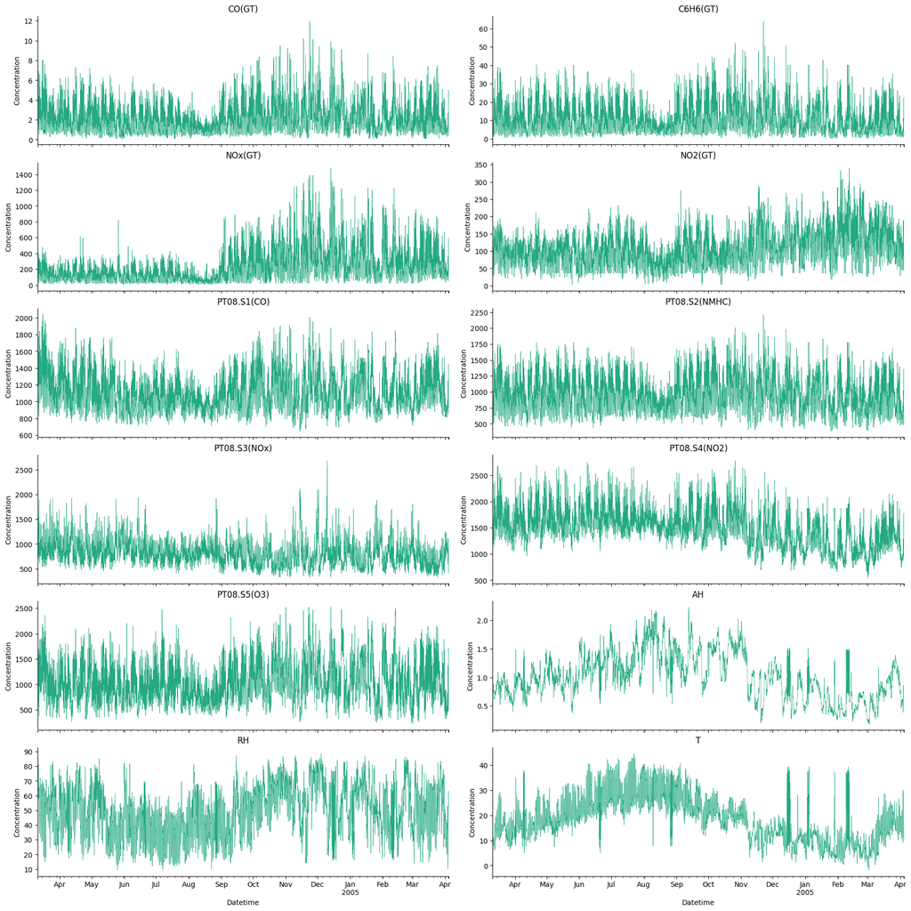

```python
fields_to_plot = gt_fields + pt08_fields + atmos_fields
plot_graph_grid_line(df, fields_to_plot, 'Datetime', graphs_per_row=2, y_label='Concentration')
```

## Distribution Plots

I am now going to explore the distribution of values for each feature. Again, I have written a similar procedure to flexibly plot the graphs into a grid.

```python
def plot_graph_grid_histplot(df, fields_to_plot, graphs_per_row=3, y_label = ""):

    # Calculate the number of rows needed for the subplots
    _no_fields_to_plot = len(fields_to_plot)
    _graph_rows = math.ceil( (_no_fields_to_plot / graphs_per_row))

    # Create new plot grid (shared y-axis as scale is comparible)
    fig, axs = plt.subplots(_graph_rows,graphs_per_row, figsize=(18, 18), sharex=False, sharey=True, constrained_layout=True)

    # Set the starting location ot the top left corner of the grid
    _location_x = _location_y = 0

    # Loop through the fields to create subplots
    for _field in fields_to_plot:

        print (f"{Fore.YELLOW}[PLOT]{Fore.RESET} Plotting field: {_field}")

        # Plot the chart at the correct location in the grid
        sns.histplot(data=df, x=_field, kde=True, ax=axs[_location_x, _location_y], color='#25a983')

        # Labels
        axs[_location_x, _location_y].set_title(_field)
        axs[_location_x, _location_y].set_ylabel(y_label)
        axs[_location_x, _location_y].set_xlabel("")

        # Move to the next location in the grid
        if _location_y < (graphs_per_row - 1):
            _location_y += 1
        else:
            _location_y = 0
            _location_x += 1
```

```
[PLOT] Plotting field: CO(GT)
[PLOT] Plotting field: C6H6(GT)
[PLOT] Plotting field: NOx(GT)
[PLOT] Plotting field: NO2(GT)
[PLOT] Plotting field: PT08.S1(CO)
[PLOT] Plotting field: PT08.S2(NMHC)
[PLOT] Plotting field: PT08.S3(NOx)
[PLOT] Plotting field: PT08.S4(NO2)
[PLOT] Plotting field: PT08.S5(O3)
[PLOT] Plotting field: AH
[PLOT] Plotting field: RH
[PLOT] Plotting field: T
```

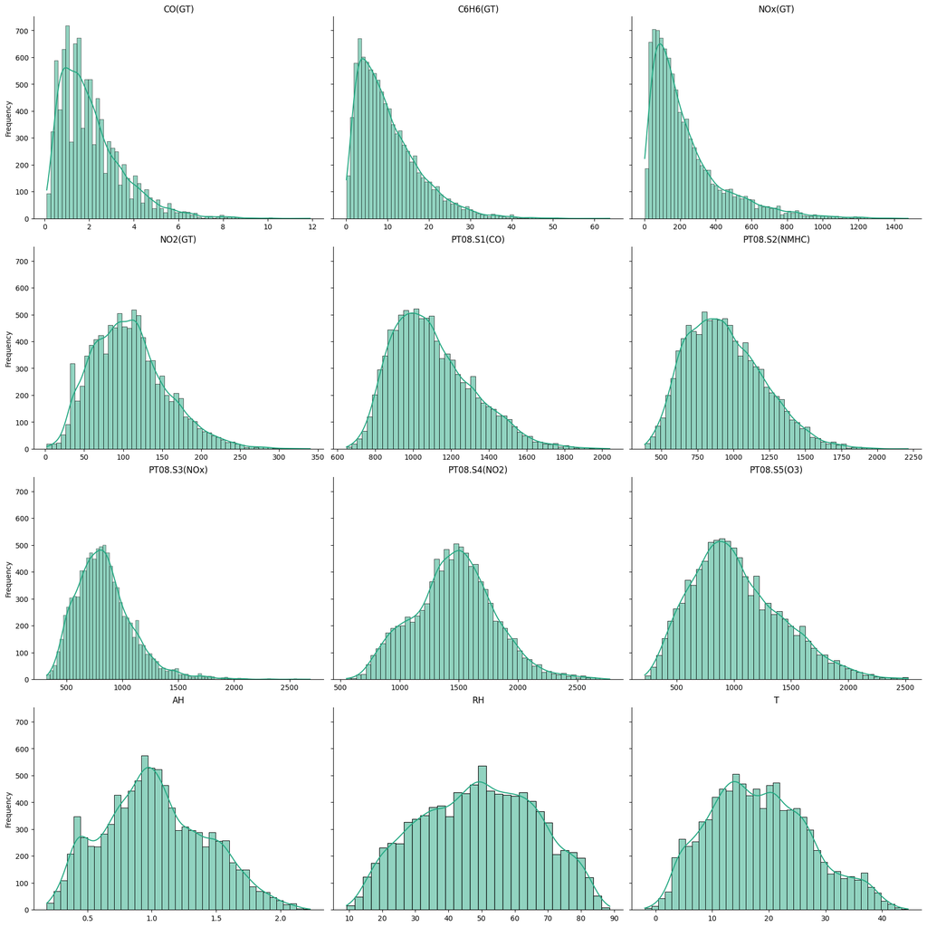

```python
fields_to_plot = gt_fields + pt08_fields + atmos_fields
plot_graph_grid_histplot(df, fields_to_plot, graphs_per_row=3, y_label="Frequency")
```

## Correlation between Features

In order to check for any correlation between features, I will select only the numerical features; all other columns are dropped. Note that month and weekday are still represented as I generated a MonthNo and WeekdayNo feature earlier.

Firstly, here is the Pearson correlation matrix in numbers. Then the following code creates a heatmap to show the Pearson correlation between these fields.

```python
# Filter the dataframe for numerical columns only
numerical_df = df.select_dtypes(include=[np.number]).drop('index', axis=1, errors='ignore')
numerical_df.corr(method='pearson').round(2)
```

|  | CO(GT) | PT08.S1(CO) | C6H6(GT) | PT08.S2(NMHC) | NOx(GT) | PT08.S3(NOx) | NO2(GT) | PT08.S4(NO2) | PT08.S5(O3) | T | RH | AH | Hour | WeekdayNo | MonthNo |
| --- | --- | --- | --- | --- | --- | --- | --- | --- | --- | --- | --- | --- | --- | --- | --- |
| CO(GT) | 1.00 | 0.87 | 0.92 | 0.90 | 0.80 | -0.70 | 0.70 | 0.62 | 0.85 | 0.04 | 0.01 | 0.04 | 0.36 | -0.13 | 0.09 |
| PT08.S1(CO) | 0.87 | 1.00 | 0.87 | 0.89 | 0.71 | -0.76 | 0.65 | 0.68 | 0.90 | 0.05 | 0.11 | 0.13 | 0.33 | -0.07 | -0.04 |
| C6H6(GT) | 0.92 | 0.87 | 1.00 | 0.98 | 0.73 | -0.73 | 0.64 | 0.76 | 0.86 | 0.21 | -0.08 | 0.17 | 0.34 | -0.17 | 0.12 |
| PT08.S2(NMHC) | 0.90 | 0.89 | 0.98 | 1.00 | 0.72 | -0.79 | 0.67 | 0.77 | 0.88 | 0.25 | -0.11 | 0.19 | 0.39 | -0.15 | 0.12 |
| NOx(GT) | 0.80 | 0.71 | 0.73 | 0.72 | 1.00 | -0.65 | 0.77 | 0.27 | 0.78 | -0.21 | 0.15 | -0.14 | 0.25 | -0.11 | 0.13 |
| PT08.S3(NOx) | -0.70 | -0.76 | -0.73 | -0.79 | -0.65 | 1.00 | -0.64 | -0.54 | -0.79 | -0.16 | -0.04 | -0.24 | -0.32 | 0.07 | -0.07 |
| NO2(GT) | 0.70 | 0.65 | 0.64 | 0.67 | 0.77 | -0.64 | 1.00 | 0.20 | 0.71 | -0.14 | -0.12 | -0.31 | 0.39 | -0.10 | -0.18 |
| PT08.S4(NO2) | 0.62 | 0.68 | 0.76 | 0.77 | 0.27 | -0.54 | 0.20 | 1.00 | 0.59 | 0.56 | -0.05 | 0.63 | 0.22 | -0.12 | 0.17 |
| PT08.S5(O3) | 0.85 | 0.90 | 0.86 | 0.88 | 0.78 | -0.79 | 0.71 | 0.59 | 1.00 | -0.02 | 0.12 | 0.07 | 0.25 | -0.12 | 0.05 |
| T | 0.04 | 0.05 | 0.21 | 0.25 | -0.21 | -0.16 | -0.14 | 0.56 | -0.02 | 1.00 | -0.59 | 0.66 | 0.20 | -0.01 | 0.26 |
| RH | 0.01 | 0.11 | -0.08 | -0.11 | 0.15 | -0.04 | -0.12 | -0.05 | 0.12 | -0.59 | 1.00 | 0.15 | -0.29 | 0.03 | 0.08 |
| AH | 0.04 | 0.13 | 0.17 | 0.19 | -0.14 | -0.24 | -0.31 | 0.63 | 0.07 | 0.66 | 0.15 | 1.00 | -0.02 | 0.01 | 0.41 |
| Hour | 0.36 | 0.33 | 0.34 | 0.39 | 0.25 | -0.32 | 0.39 | 0.22 | 0.25 | 0.20 | -0.29 | -0.02 | 1.00 | 0.00 | -0.00 |
| WeekdayNo | -0.13 | -0.07 | -0.17 | -0.15 | -0.11 | 0.07 | -0.10 | -0.12 | -0.12 | -0.01 | 0.03 | 0.01 | 0.00 | 1.00 | -0.01 |
| MonthNo | 0.09 | -0.04 | 0.12 | 0.12 | 0.13 | -0.07 | -0.18 | 0.17 | 0.05 | 0.26 | 0.08 | 0.41 | -0.00 | -0.01 | 1.00 |

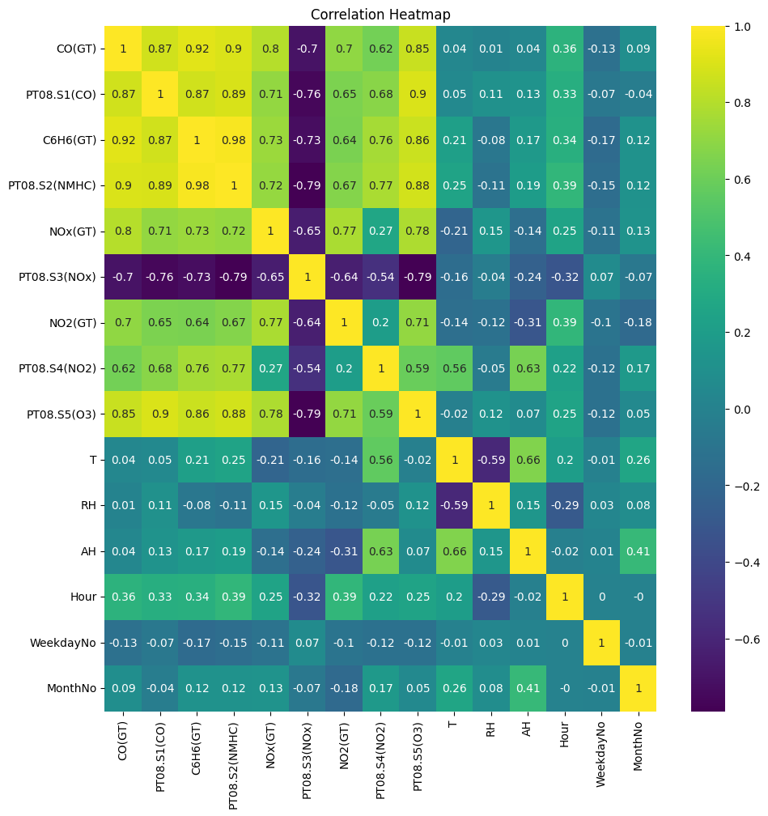

```python
# Create new plot
plt.figure(figsize=(11, 11))

# Apply rounding to 2 decimal places for better readability
sns.heatmap(numerical_df.corr(method='pearson').round(2),annot=True, cmap='viridis')
plt.title('Correlation Heatmap')
plt.show()
```

The strongest positive correlations are between the presence of various pollutants, implying that they are related to one another and are likely produced by the same source. This was not absolutely certain until this point. It was possible that some pollutants are produced by vehicles, while others by a localised polluter, such as a factory. However, this chart appears to show that the presence of a high concentration of one pollutant would be, to a greater or lesser degree, a predictor of nearly any another pollutant in the feature set, save for PT08.S3(NOx).

The following plot shows only the pollutants:

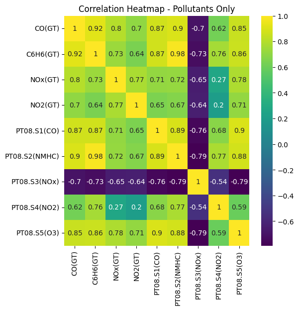

```python
numerical_df = df[gt_fields + pt08_fields]

# Create new plot
plt.figure(figsize=(6, 6))

# Apply rounding to 2 decimal places for better readability
sns.heatmap(numerical_df.corr(method='pearson').round(2),annot=True, cmap='viridis')
plt.title('Correlation Heatmap - Pollutants Only')
plt.show()
```

The following heatmap show the other numeric features, including both humidity figures and temperature.

The strongest negative correlation is between temperature and relative humidity (RH). Warmer air can hold more water vapour. As the temperature rises but if no additional moisture is added, the relative humidity drops. There is also a strong positive correlation between temperature and actual humidity. Actual Humidity (AH) is a measure of the amount of water vapour in the air, which can increase or decrease depending on other environmental factors.

There is also a correlation between the month and AH, which is also intuitively correct; we know that there is more water in the air in some months, either due to heat or due to the weather being wetter.

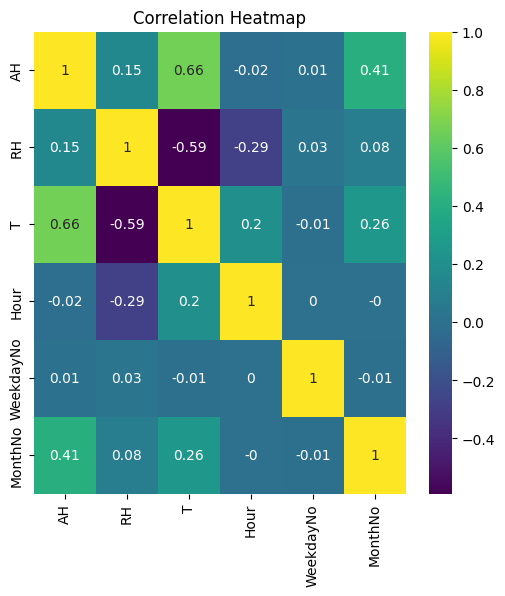

```python
numerical_df = df[atmos_fields + ['Hour'] + ['WeekdayNo'] + ['MonthNo']]

# Create new plot
plt.figure(figsize=(6, 6))

# Apply rounding to 2 decimal places for better readability
sns.heatmap(numerical_df.corr(method='pearson').round(2),annot=True, cmap='viridis')
plt.title('Correlation Heatmap')
plt.show()
```

## Averaged Data - Monthly, Weekly and Daily

The following charts show the monthly, weekly and daily averages for normalised data. Normalising the data means that these features can be shown relative to one another on the same graph. This is necessary as the concentrations vary wildly in absolute terms.

The following function handles plotting the resampled data:

```python
def plot_multi_line_graph(df, fields_to_plot, resample="M", title=""):

    # Generate a list of colours based on the number of fields to plot
    # Space them out evenly across the colour map
    cmap = plt.get_cmap('viridis')
    colours = [cmap(i) for i in np.linspace(0, 1, len(fields_to_plot))]

    # Create new plot
    plt.figure(figsize=(8, 5))

    # Loop through the fields to plot ('i' will be used for colour)
    for i, field in enumerate(fields_to_plot):

        # Resample to Monthly frequency and calculate the mean
        average = df[field].resample(resample).mean()
        average.plot(kind='line', color=colours[i])
        plt.xlabel('Date')
        plt.ylabel('Relative Concentration')

    plt.legend(fields_to_plot, loc='upper right', bbox_to_anchor=(1.30, 1))
    plt.title(title, fontsize=14)
    plt.show()
```

The following code filters the wanted fields from the dataset, normalises them and plots the graphs using the function above.

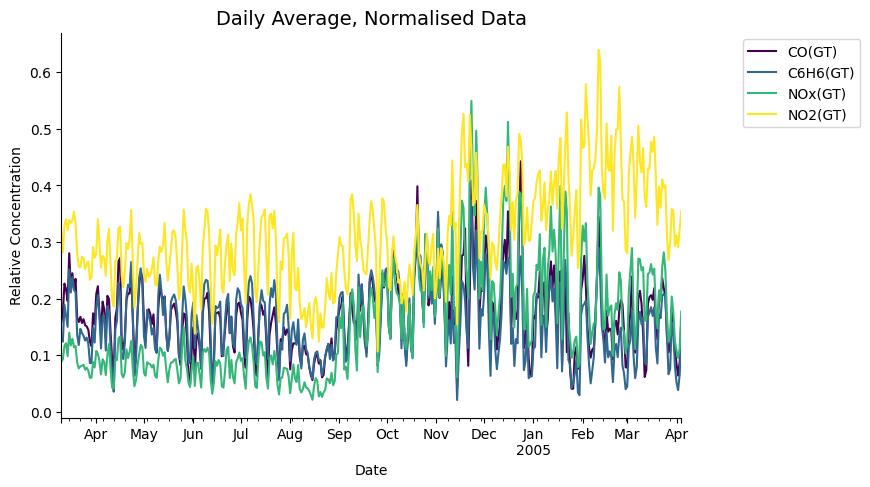

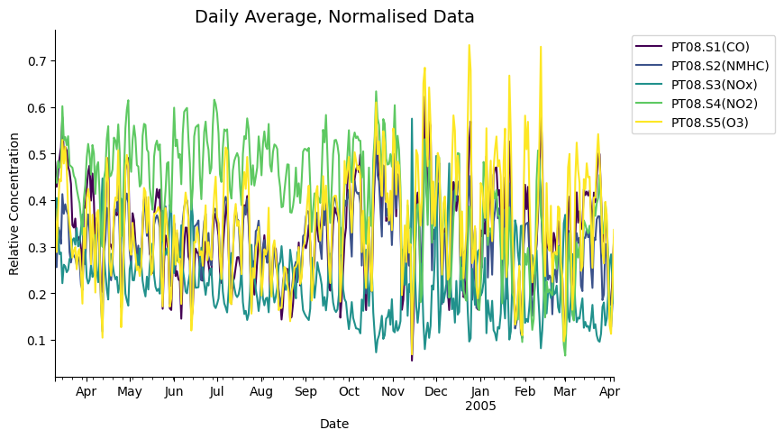

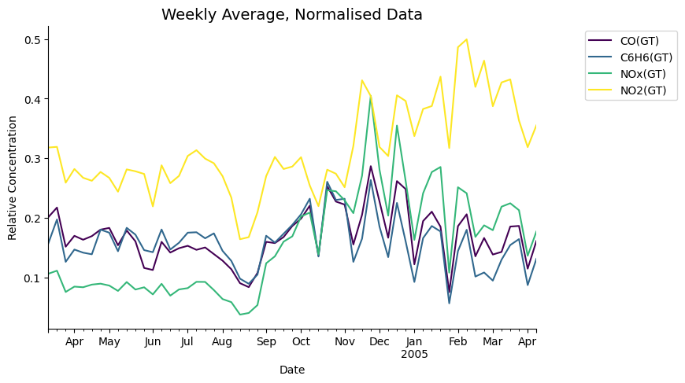

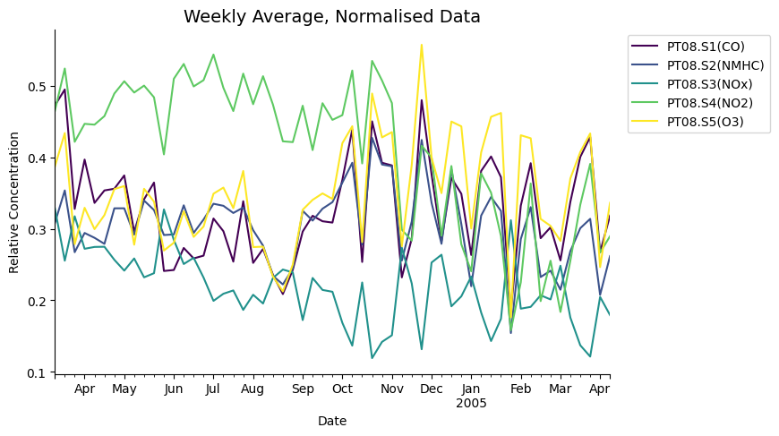

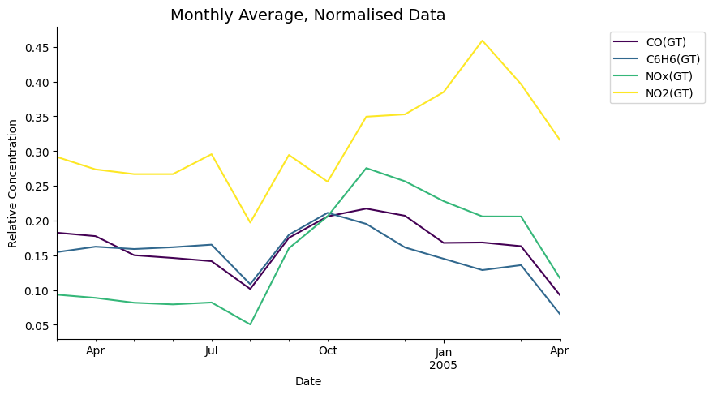

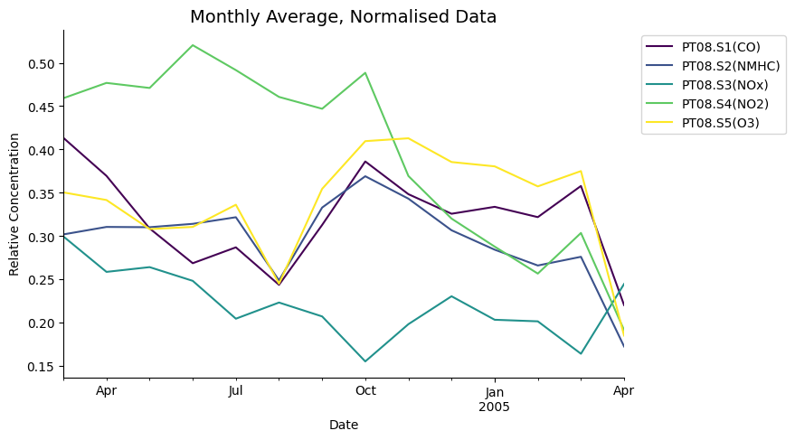

```python
# Filter the dataframe
fields_to_plot = gt_fields + pt08_fields
plot_df = df[fields_to_plot + ['Datetime']]

# Set datetime as index
plot_df.set_index('Datetime', inplace=True)

# Normalise the data fields
scaler = MinMaxScaler()
plot_df[fields_to_plot] = scaler.fit_transform(plot_df[fields_to_plot])

# Use the function above to plot the graphs
plot_multi_line_graph(plot_df, gt_fields, resample="D", title="Daily Average, Normalised Data")
plot_multi_line_graph(plot_df, pt08_fields, resample="D", title="Daily Average, Normalised Data")
plot_multi_line_graph(plot_df, gt_fields, resample="W", title="Weekly Average, Normalised Data")
plot_multi_line_graph(plot_df, pt08_fields, resample="W", title="Weekly Average, Normalised Data")
plot_multi_line_graph(plot_df, gt_fields, resample="M", title="Monthly Average, Normalised Data")
plot_multi_line_graph(plot_df, pt08_fields, resample="M", title="Monthly Average, Normalised Data")
```

This plot shows the lack of correlation between the Ground Truth value and the corresponding sensor response value. This chart shows that they are in opposition!

On this basis, I am dropping this feature.

[figure not shown]

```python
plotme = ['NOx(GT)'] + ['PT08.S3(NOx)']
plot_multi_line_graph(plot_df, plotme, resample="W", title="Monthly Average, Normalised Data")
```

```python
df.drop(columns=['PT08.S3(NOx)'], inplace=True)
pt08_fields.remove('PT08.S3(NOx)')
```

# Answering the Questions

Having explored the data, I believe that I am now able to answer the analytical questions posed above.

To reitereate:

Is it possible to predict future pollution levels based on historical data?

And can this be used to inform residents of the city about potentially risky times, and when to take precautions or to avoid going outside without a mask?

## Have the Pollutant Levels Ever Exceeded Legal Safety Limits?

Is there a problem with the levels of pollutants in the air around the monitoring station? It is difficult to find standardised legal limits for each of the chemicals in the dataset. The data was gathered twenty years ago in 2004-2005. The World Health Organisation has proposed stricter limits since this time, but the legal limits expected by countries vary wildly. For instance, Russia allows an average of 100 microg/m<sup>3</sup> of benzene (C<sub>6</sub>H<sub>6</sub>) over 24 hours, while the EU recommends only 3.25 microg/m<sup>3</sup> in the same time period.

I have been able to find sensible values for safety limits for the following chemicals, which I will use to compare against the data to see how often these are breached. Again, it is important to note that the data was gathered 20 years ago, and safety in many countries is much more stringent now, while cars are subsequently much less polluting.

| Pollutant | 1 hour Safe Level | 8 hour Safe Level | 24 hour Safe Level |
| --- | --- | --- | --- |
| CO | 30 mg/m<sup>3</sup> | 10 mg/m<sup>3</sup> | 4 mg/m<sup>3</sup> |
| C<sub>6</sub>H<sub>6</sub> | 35 microg/m<sup>3</sup> |  | 3.25 microg/m<sup>3</sup> |
| NMHC | - | - | - |
| NO<sub>x</sub> | - | - | - |
| NO<sub>2</sub> | 200 microg/m<sup>3</sup> | - | 25 microg/m<sup>3</sup> |

References:

- (WHO, 2021 pp 135-136)
- (EU, 2022)
- (Lane, 2021)

A reminder of the units in the provided dataset, showing that these values can be compared directly:

| Variable Name | Units |
| --- | --- |
| CO(GT) | mg/m<sup>3</sup> |
| NMHC(GT) | microg/m<sup>3</sup> |
| C6H6(GT) | microg/m<sup>3</sup> |
| NOx(GT) | ppb |
| NO2(GT) | microg/m<sup>3</sup> |

```python
# Define dictionary structure for maximum safe level averages
safe_level = {
                'CO':   {'1hr': 30.0, '8hr': 10.0, '24hr': 4.0},
                'C6H6': {'1hr': 35.0, '24hr': 3.25},
                'NO2':  {'1hr': 200.0, '24hr': 25.0}
            }

# Filter the dataframe
plot_df = df[['Datetime'] + gt_fields]
plot_df.set_index('Datetime', inplace=True)

total_slots = plot_df.shape[0]
eight_hour_slots = total_slots / 3
daily_slots = total_slots / 24

# Loop through the pollutants for which we have a 'safe level' value available
for chemical in safe_level:

    feature = chemical+"(GT)"

    # Set the number of times exceeded to 'unknown'
    number_exceeded_daily = number_exceeded_8hourly = number_exceeded_hourly = -1
    exceeded_dates_daily = []

    # If we have a 'save level' value, work on it.
    # Each is slightly different, so no further loop...

    if '24hr' in safe_level[chemical].keys():
        # Get a 24 hour average
        daily_average = plot_df[feature].resample('D').mean()
        number_exceeded_daily = (daily_average > safe_level[chemical]['24hr']).sum()

        # Which dates exceeded the 24 hour average
        #exceeded_dates_daily = daily_average[daily_average > safe_level[chemical]['24hr']].index

    if '8hr' in safe_level[chemical].keys():
        # Get a 8 hour average
        eighthourly_average = plot_df[feature].resample('8h').mean()
        number_exceeded_8hourly = (eighthourly_average > safe_level[chemical]['8hr']).sum()

    if '1hr' in safe_level[chemical].keys():
        # The values in the dataset are already averaged to one hour
        number_exceeded_hourly = (plot_df[feature] > safe_level[chemical]['1hr']).sum()

    # Print the results
    print (f"{Fore.YELLOW}--- {feature} --- {Fore.RESET}")

    print (f"{Fore.CYAN}Exceeded 24 hour average:{Fore.RESET}\t", end='')
    if number_exceeded_daily != -1:
        print (f"{number_exceeded_daily} times ({round ((number_exceeded_daily / daily_slots) * 100) }%)")
    else:
        print ("Safe Level Unknown")

    # Removed as in many cases it is 100% of the days!
    #if len(exceeded_dates_daily) > 0:
    #    print (f"{Fore.CYAN} - On the following dates:{Fore.RESET}")
    #    print (exceeded_dates_daily)
    #    print ()

    print (f"{Fore.CYAN}Exceeded 8 hour average:{Fore.RESET}\t", end='')
    if number_exceeded_8hourly != -1:
        print (f"{number_exceeded_8hourly} times ({round ((number_exceeded_8hourly / eight_hour_slots) * 100) }%)")
    else:
        print ("Safe Level Unknown")

    print (f"{Fore.CYAN}Exceeded 1 hour average:{Fore.RESET}\t", end='')
    if number_exceeded_hourly != -1:
        print (f"{number_exceeded_hourly} times ({round ((number_exceeded_hourly / total_slots) * 100) }%)")
    else:
        print ("Safe Level Unknown")

    print ()
```

```
--- CO(GT) ---
Exceeded 24 hour average:	8 times (2%)
Exceeded 8 hour average:	0 times (0%)
Exceeded 1 hour average:	0 times (0%)

--- C6H6(GT) ---
Exceeded 24 hour average:	381 times (98%)
Exceeded 8 hour average:	Safe Level Unknown
Exceeded 1 hour average:	94 times (1%)

--- NO2(GT) ---
Exceeded 24 hour average:	391 times (100%)
Exceeded 8 hour average:	Safe Level Unknown
Exceeded 1 hour average:	400 times (4%)
```

This data shows that the levels of pollution in the year 2004-2005 often exceeded safe levels, particularly when averaged over a 24 hours period. This supports the need to answer these questions, and provide means to make changes.

## Heatmaps Showing Hour, Weekday, Month and Pollutant Levels

I have realised that it may be possible to give a partial answer to the second question without performing any further statistical analysis of the data set. (I will continue on to do this after the next section.)

I will now draw a number of heatmaps showing pollutant concentration for:

- Hour vs Weekday
- Hour vs Month
- Weekday vs Month

This will broadly show the times of day and time of the year when various pollutants (or other features) have the greatest value.

The following function is similar to previous 'multi-graph' functions user previously, but for heat maps.

```python
def plot_graph_grid_heatmap(df, fields_to_plot, row_field, column_field, graphs_per_row=3):

    # Calculate the number of rows needed for the subplots
    _no_fields_to_plot = len(fields_to_plot)
    _graph_rows = math.ceil( (_no_fields_to_plot / graphs_per_row))

    # Create new plot grid (shared y-axis as scale is comparible)
    fig, axs = plt.subplots(_graph_rows,graphs_per_row, figsize=(18, 18), sharex=True, sharey=True, constrained_layout=True)

    # Set the starting location ot the top left corner of the grid
    _location_x = _location_y = 0

    # Loop through the fields to create subplots
    for _field in fields_to_plot:

        print (f"{Fore.YELLOW}[PLOT]{Fore.RESET} Plotting field: {_field}")

        # Pivot the data to get hours as rows and weekdays as columns
        pivot_table = plot_df.pivot_table(values=_field, index=row_field, columns=column_field, aggfunc='mean')

        # Annot set to False as the colour gives more impact than the number
        sns.heatmap(pivot_table, annot=False, cbar=False, cmap='viridis',ax=axs[_location_x, _location_y])

        # Labels
        axs[_location_x, _location_y].set_title(_field)
        axs[_location_x, _location_y].set_ylabel(row_field)
        axs[_location_x, _location_y].set_xlabel(column_field)

        # Move to the next location in the grid
        if _location_y < (graphs_per_row - 1):
            _location_y += 1
        else:
            _location_y = 0
            _location_x += 1


    plt.show();
```

I am also going to plot the 'atmospheric' features alongside the pollution values to show how these vary throughout the day and the year.

```
[PLOT] Plotting field: CO(GT)
[PLOT] Plotting field: C6H6(GT)
[PLOT] Plotting field: NOx(GT)
[PLOT] Plotting field: NO2(GT)
[PLOT] Plotting field: PT08.S1(CO)
[PLOT] Plotting field: PT08.S2(NMHC)
[PLOT] Plotting field: PT08.S4(NO2)
[PLOT] Plotting field: PT08.S5(O3)
[PLOT] Plotting field: AH
[PLOT] Plotting field: RH
[PLOT] Plotting field: T
```

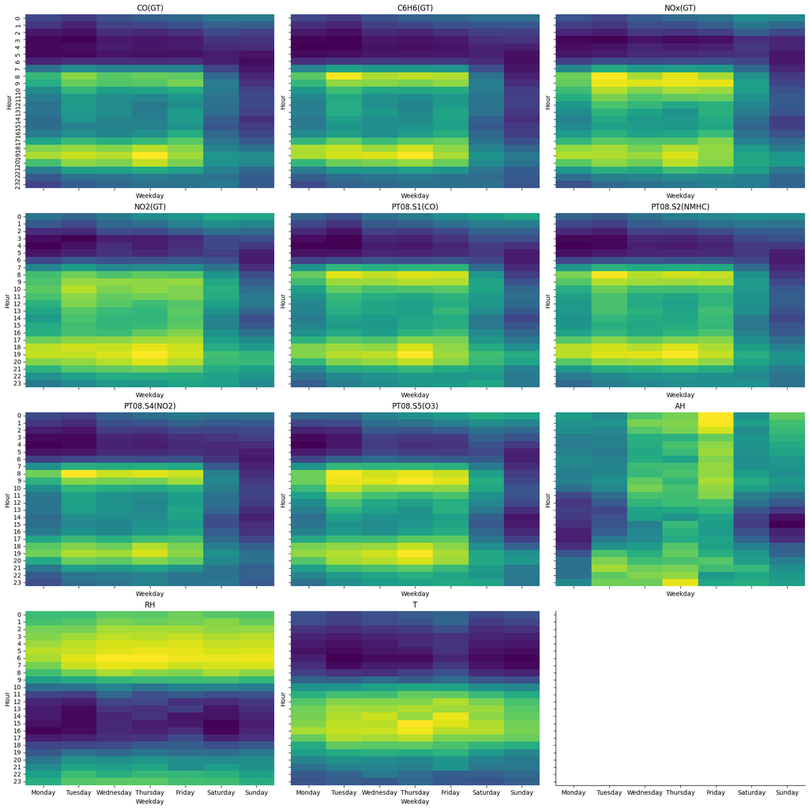

```python
# Filter the dataframe
fields_to_plot = gt_fields + pt08_fields + atmos_fields
plot_df = df[['Datetime', 'Hour', 'Weekday', 'Month'] + fields_to_plot]

# Plot the heatmaps Hour and Weekday
plot_graph_grid_heatmap (plot_df, fields_to_plot, 'Hour', 'Weekday')
```

```
[PLOT] Plotting field: CO(GT)
[PLOT] Plotting field: C6H6(GT)
[PLOT] Plotting field: NOx(GT)
[PLOT] Plotting field: NO2(GT)
[PLOT] Plotting field: PT08.S1(CO)
[PLOT] Plotting field: PT08.S2(NMHC)
[PLOT] Plotting field: PT08.S4(NO2)
[PLOT] Plotting field: PT08.S5(O3)
[PLOT] Plotting field: AH
[PLOT] Plotting field: RH
[PLOT] Plotting field: T
```

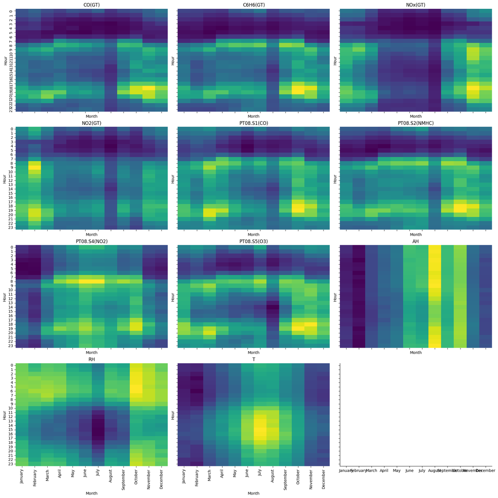

```python
# Plot the heatmaps Hour and Month
plot_graph_grid_heatmap (plot_df, fields_to_plot, 'Hour', 'Month')
```

```
[PLOT] Plotting field: CO(GT)
[PLOT] Plotting field: C6H6(GT)
[PLOT] Plotting field: NOx(GT)
[PLOT] Plotting field: NO2(GT)
[PLOT] Plotting field: PT08.S1(CO)
[PLOT] Plotting field: PT08.S2(NMHC)
[PLOT] Plotting field: PT08.S4(NO2)
[PLOT] Plotting field: PT08.S5(O3)
[PLOT] Plotting field: AH
[PLOT] Plotting field: RH
[PLOT] Plotting field: T
```

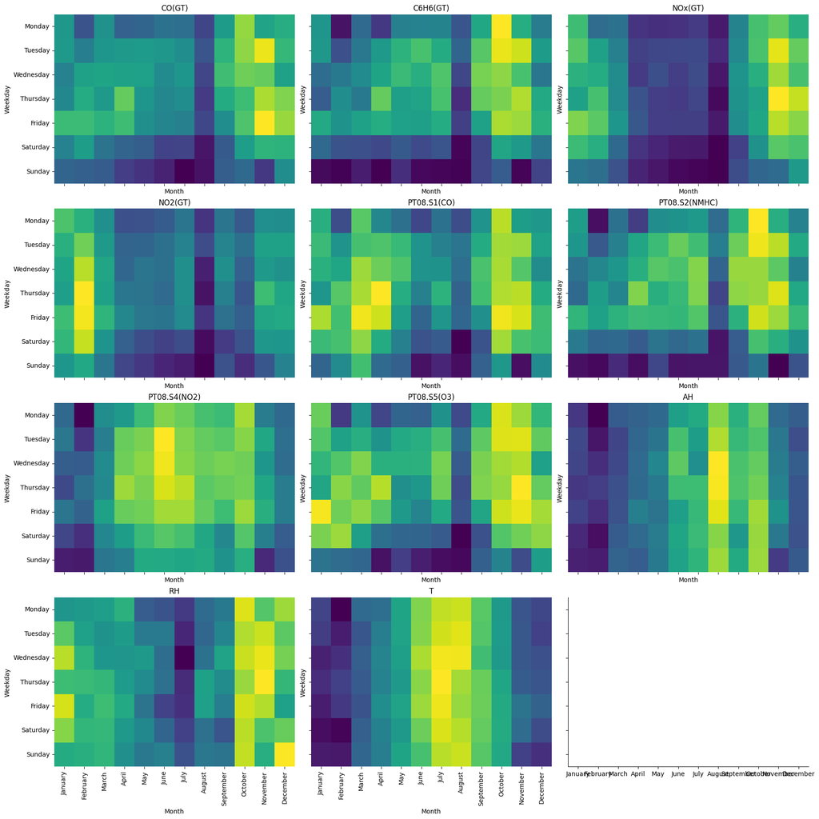

```python
# Plot the heatmaps Weekday and Month
plot_graph_grid_heatmap (plot_df, fields_to_plot, 'Weekday', 'Month')
```

### Combined Heatmaps

The following heatmaps combine normalised pollutant features. This is justified because all the pollutants correlate positively.

This is the chart that will be taken forward into the analytical report and presentation.

[output not shown]

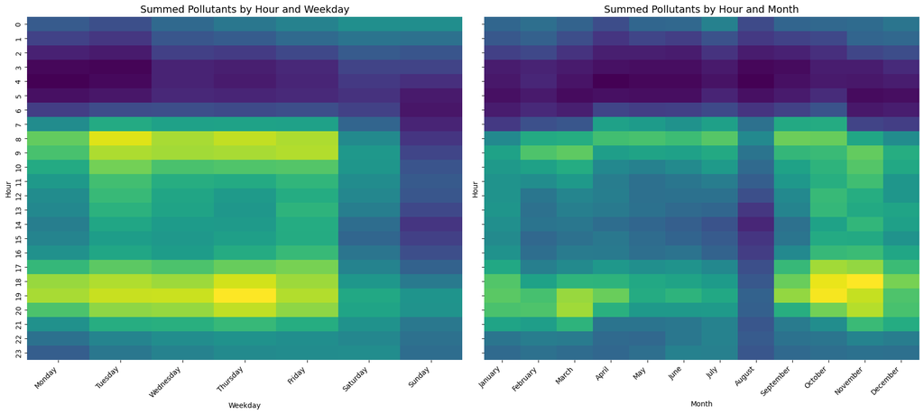

```python
# Filter the dataframe
fields_to_plot = gt_fields + pt08_fields
plot_df = df[fields_to_plot + ['Hour'] + ['Weekday'] + ['Month']]

# Normalise the data fields
scaler = MinMaxScaler()
plot_df[fields_to_plot] = scaler.fit_transform(plot_df[fields_to_plot])
plot_df['Pollutants'] = plot_df[fields_to_plot].sum(axis=1)

# Create new plot grid (shared y-axis as scale is comparible)
fig, axs = plt.subplots(1,2, figsize=(18, 8), sharex=False, sharey=True, constrained_layout=True)

# Pivot the data to get hours as rows and weekdays as columns
pivot_table = plot_df.pivot_table(values='Pollutants', index='Hour', columns='Weekday', aggfunc='mean')
# Annot set to False as the colour gives more impact than the number
sns.heatmap(pivot_table, annot=False, cbar=False, cmap='viridis', ax=axs[0])
# Pivot the data to get hours as rows and weekdays as columns
pivot_table = plot_df.pivot_table(values='Pollutants', index='Hour', columns='Month', aggfunc='mean')
# Annot set to False as the colour gives more impact than the number
sns.heatmap(pivot_table, annot=False, cbar=False, cmap='viridis', ax=axs[1])

# Labels
axs[0].set_title('Summed Pollutants by Hour and Weekday', fontsize=14)
axs[0].set_ylabel('Hour')
axs[0].set_xlabel('Weekday')
axs[0].set_xticklabels(axs[0].get_xticklabels(), rotation=45, ha='right')
axs[1].set_title('Summed Pollutants by Hour and Month', fontsize=14)
axs[1].set_ylabel('Hour')
axs[1].set_xlabel('Month')
axs[1].set_xticklabels(axs[1].get_xticklabels(), rotation=45, ha='right')
```

### Calendar plots

The following code creates another view of this data, presented as a calendar-style heatmap, showing individual days over the year of study.

```python
def plot_graph_grid_calendars(df, fields_to_plot, graphs_per_row=3):

    # Calculate the number of rows needed for the subplots
    _no_fields_to_plot = len(fields_to_plot)
    _graph_rows = math.ceil( (_no_fields_to_plot / graphs_per_row))

    # Create new plot grid (shared y-axis as scale is comparible)
    fig, axs = plt.subplots(_graph_rows,graphs_per_row, figsize=(18, 18), sharex=True, sharey=True, constrained_layout=True)

    # Set the starting location ot the top left corner of the grid
    _location_x = _location_y = 0

    # Set datetime as index
    df.set_index('Datetime', inplace=True)
    # Ensure daily frequency and fill missing values
    df = df.resample('D').mean()

    # Extract date components
    df['Year'] = df.index.year
    df['Month'] = df.index.month
    df['Day'] = df.index.day

    # Loop through the fields to create subplots
    for _field in fields_to_plot:

        print (f"{Fore.YELLOW}[PLOT]{Fore.RESET} Plotting field: {_field}")

        # Create a pivot table: average CO(GT) by day and month
        pivot_table = df.pivot_table(values=_field, index='Month', columns='Day', aggfunc='mean')

        # Annot set to False as the colour gives more impact than the number
        sns.heatmap(pivot_table, annot=False, cbar=False, cmap='viridis',ax=axs[_location_x, _location_y])

        # Labels
        axs[_location_x, _location_y].set_title(_field)
        axs[_location_x, _location_y].set_ylabel("Month")
        axs[_location_x, _location_y].set_xlabel("Day")

        # Move to the next location in the grid
        if _location_y < (graphs_per_row - 1):
            _location_y += 1
        else:
            _location_y = 0
            _location_x += 1


    plt.show();
```

```
[PLOT] Plotting field: CO(GT)
[PLOT] Plotting field: C6H6(GT)
[PLOT] Plotting field: NOx(GT)
[PLOT] Plotting field: NO2(GT)
[PLOT] Plotting field: PT08.S1(CO)
[PLOT] Plotting field: PT08.S2(NMHC)
[PLOT] Plotting field: PT08.S4(NO2)
[PLOT] Plotting field: PT08.S5(O3)
```

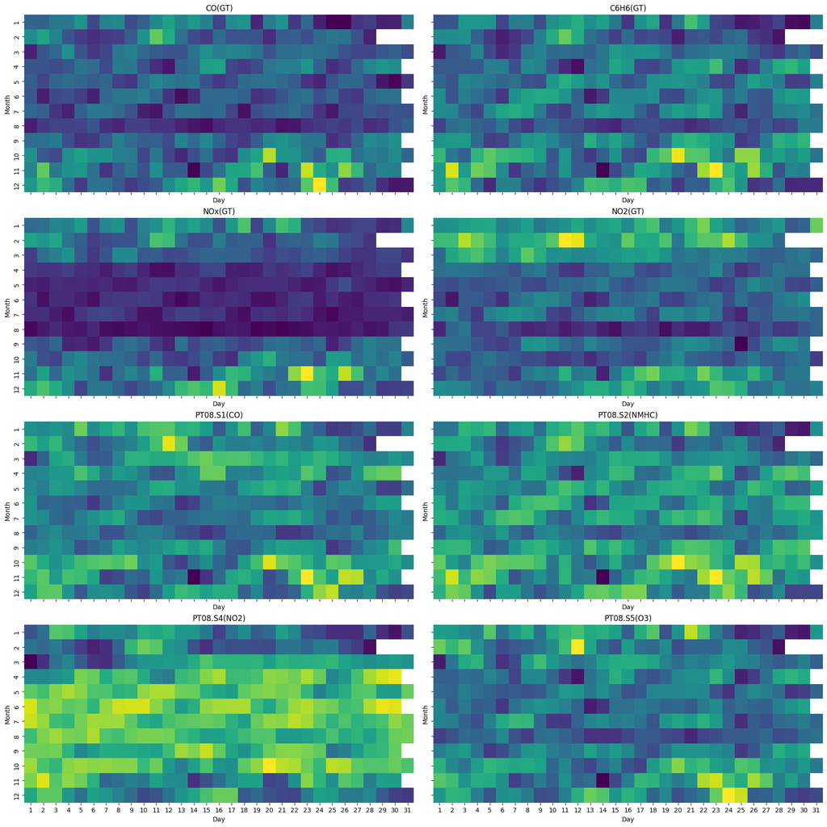

```python
fields_to_plot = gt_fields + pt08_fields

plot_df = df[['Datetime'] + fields_to_plot]
plot_graph_grid_calendars(plot_df, fields_to_plot, graphs_per_row=2)
```

These are quite pretty, but do not really add much to the analysis with reference towards the questions.

## NARMAX Regression Analysis

In order to determine whether past values can be used to predicy future pollution levels, I will carry out a regression analysis. I intend to use a NARMAX model, as the data appears to be non-linear and varies over time.

I am attempting to make use of the System Identification library called sysidentpy.

Information about this module is available at: https://sysidentpy.org/

The following function creates a NARMAX model using the Baysian Ridge estimator.

```python
def train_and_fit_model(X, y,field_name, xlag=[1,2], ylag=[1,2]):

    # Normalise the data
    scaler_x = MinMaxScaler()
    scaler_y = MinMaxScaler()
    X_scaled = scaler_x.fit_transform(X.reshape(-1, 1))
    y_scaled = scaler_y.fit_transform(y.reshape(-1, 1))

    # Reshape X and y to 2D arrays
    #X_scaled = X.reshape(-1, 1)
    #y_scaled = y.reshape(-1, 1)

    # Defined when calling the function
    #xlag = [1,2]
    #ylag = [1,2]

    # Tried FROLS model, but it gave very poor results
    #model = FROLS(xlag=xlag, ylag=xlag, basis_function=Polynomial(degree=2), model_type="NARMAX")

    # Define and fit NARMAX model
    model = NARX( base_estimator=BayesianRidge(), xlag=xlag, ylag=ylag, basis_function=Polynomial(degree=2), model_type="NARMAX")

    model.fit(X=X_scaled, y=y_scaled)
    y_pred = model.predict(X=X_scaled, y=y_scaled)

    plot_narmax_model(y_scaled, y_pred, field_name, title=f"NARMAX Model Predictions vs Actual {field_name} Values")
    return y_pred

# Plot the actual vs predicted values
def plot_narmax_model (y, y_pred, field, title):
    plt.figure(figsize=(12, 6))
    plt.plot(y, label='Actual', color='#25a983')
    plt.plot(y_pred, label='Predicted', color='yellow')
    plt.xlabel("Time Slot")
    plt.ylabel(f"Nomalised {field} Values")
    plt.title(title)
    plt.legend()
    plt.grid(True)
    plt.tight_layout()
    plt.show()
```

Training a single model to work out lags

```
[NARMAX] Training NARMAX model for CO(GT) with xlag=1 and ylag=1
```

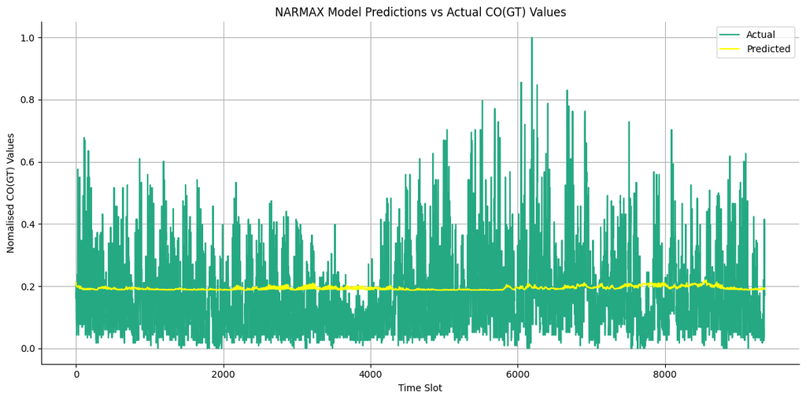

```
[NARMAX] Training NARMAX model for CO(GT) with xlag=2 and ylag=2
```

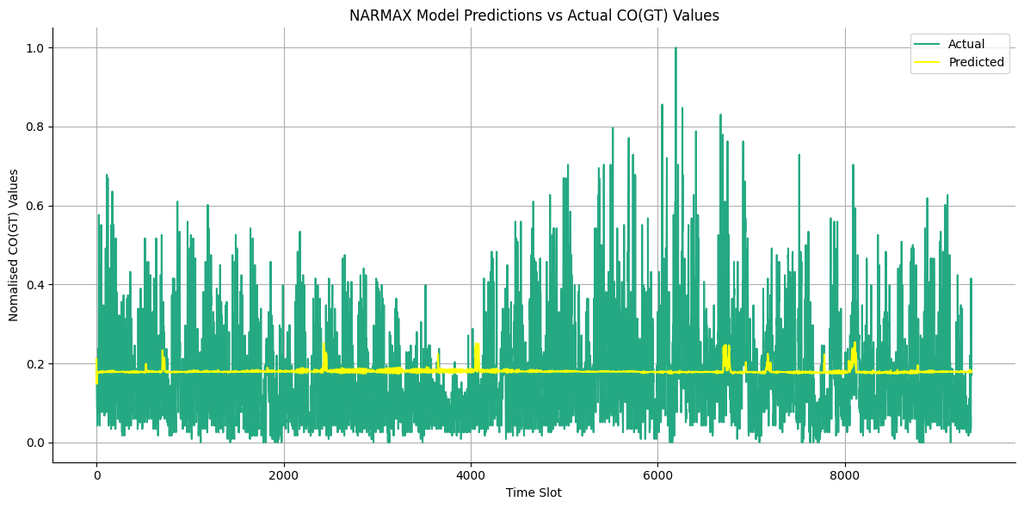

```
[NARMAX] Training NARMAX model for CO(GT) with xlag=3 and ylag=3
```

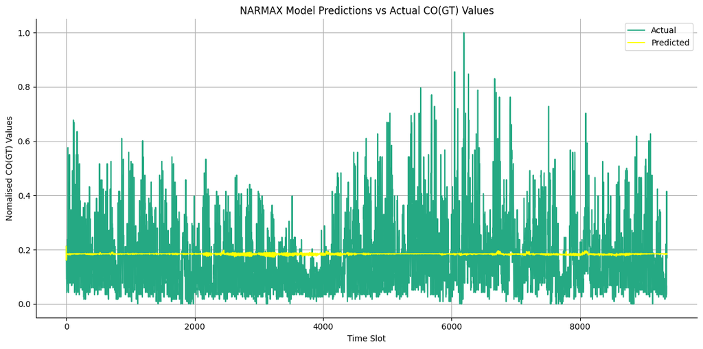

```
[NARMAX] Training NARMAX model for CO(GT) with xlag=4 and ylag=4
```

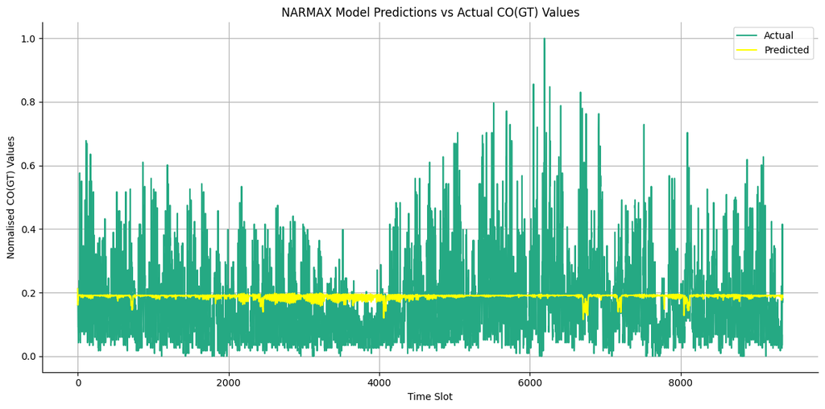

```
[NARMAX] Training NARMAX model for CO(GT) with xlag=5 and ylag=5
```

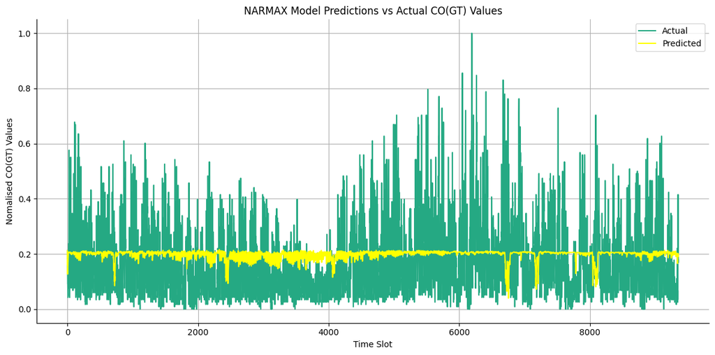

```python
field = 'CO(GT)'
for i in range (1,6):
    print (f"{Fore.YELLOW}[NARMAX]{Fore.RESET} Training NARMAX model for {field} with xlag={i} and ylag={i}")
    X = df['T'].values
    y = df[field].values
    y_pred = train_and_fit_model(X, y, field, xlag=[1,i], ylag=[1,i])
```